# Cognition and Past Tense Inflections

Ethan Weed

October 20, 2026

# Dual-route vs. single-route models

## Single-route model

When forming the past tense…

- Connectionist networks can correctly inflect verbs
- No rules needed
- Network learns the correct weights

(Rumelhart & McClelland, 1986)

## Dual-route model

When forming the past tense…

- Phonological analogy helps
- Grammatical knowledge is essential
- Homophones demostrate this

(Kim et al., 1991; Pinker & Prince, 1988)

## Homophone problem

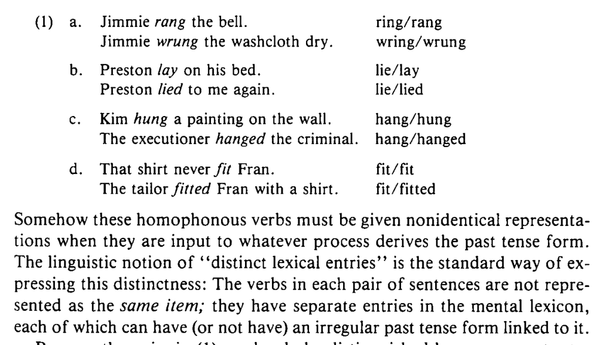

(Kim et al., 1991; Pinker & Prince, 1988)

## The dual-route model

[interactive chart not shown]

## The single-route (connectionist) model

[interactive chart not shown]

# Semantics?

## Can meaning influence inflection?

Ramscar (2002) is going to find out…

## Experiment 1 — Order effects

- pseudoword-inflection task: participants saw an inflected example of a **different, phonologically unrelated** pseudoword immediately before producing their own
- Tests whether repeated-measures designs secretly bias later responses

## Experiment 1 — Example stimulus

Example card — irregular conditionEvery Wednesday, John likes to *frow*. Last week, John **frew** a lot.

Example card — regular conditionEvery Wednesday, John likes to *frow*. Last week, John **frowed** a lot.

Target cardEvery Friday, Sam likes to *sprink*. Last week, Sam **________** a lot.

## Experiment 1 — Order effects

- **Finding:** a regular example pulled later responses toward regular forms — a genuine order effect, independent of phonology
- **Conclusion:** collect only one data point per participant in every experiment that follows

## Experiment 2 — Does meaning affect inflection?

- The same pseudoword (*sprink* / *frink*) embedded in three semantic contexts: drink-like, blink/wink-like, or an unrelated regular (*meditate*-like)
- Phonological similarity to existing verbs held constant across conditions

## Experiment 2 — Example stimulus

Drink-priming contextIn a traditional spring rite at Moscow University Hospital, the terminally ill patients all *frink* in the onset of good weather, consuming vast quantities of vodka and pickled fish. In 1996, his favorite vodka glass in hand, cancer patient Ivan Borovich **________** around 35 vodka shots and 50 pickled sprats...

Matched regular-priming (blink/wink-like) and meditate-like versions held the surrounding sentence frame phonologically identical.

## Experiment 2 — Does meaning affect inflection?

- **Finding:** meaning shifted inflection — drink-like context → mostly irregular; blink/wink-like or meditate-like context → mostly regular
- **Conclusion:** Semantic similarity can resolve the “homophone problem” dual-route theory says requires a grammatical rule

## Experiment 3 — Grammar vs. semantics

- Same pseudowords now introduced as **denominal** verbs (derived from a noun) — the grammatical-analysis hypothesis predicts automatic regularization, regardless of meaning or sound
- Independently verified: participants *did* perceive the pseudowords as denominal

## Experiment 3 — Example stimulus

Denominal, drink-priming contextA *frink* is the Muscovite equivalent of the Spanish tapas; it is served in bars, and usually comprises chilled vodka and some salted or pickled fish. In a traditional spring rite at Moscow University Hospital, the terminally ill patients all *frink* in the onset of good weather... cancer patient Ivan Borovich **________** around 35 vodka shots and 50 pickled sprats...

Same drink-priming passage as Experiment 2, with a sentence added up front that introduces *frink* as a noun first — making the verb denominal.

## Experiment 3 — Grammar vs. semantics

- **Finding:** when context still pointed toward *drink*, participants inflected irregularly anyway — denominal status didn’t override meaning
- **Conclusion:** Grammar alone doesn’t predict the pattern; semantic priming does

## Experiment 4 — Re-testing Kim et al. (1991)

- Re-ran Kim et al.’s past-tense acceptability study, but had **naive raters** — not the experimenters — independently judge each verb as denominal or deverbal
- Also re-measured “semantic reminding” as similarity *to* the irregular, not distance *from* it

## Experiment 4 — Example stimulus

Existing denominalWade Boggs has a bad habit of hitting *fly* balls and getting caught... In yesterday's game, I saw him *fly out* four times. I swear he cost us the game.

Metaphorical deverbalTim has a terrible temper. No-one knows when next he will *fly off* the handle...

Central / typical useBirds *fly* south in winter.

## Experiment 4 — Re-testing Kim et al. (1991)

- **Finding:** semantic reminding strongly predicts acceptability; once measured independently, grammatical origin does not
- **Conclusion:** The original “grammar beats semantics” result depended on the experimenters’ own, semantically-confounded classifications

## Experiment 5 — “Fly out”: memory vs. rule

- British vs. American speakers inflect the baseball term *fly out*, a denominal verb in both dialects
- Dual-route prediction: same grammatical analysis everywhere → same regular form everywhere

## Experiment 5 — Example stimulus

On an analogy with birds flying, in baseball a *fly* is a ball that is hit high into the air and is easily caught. It follows then that *to fly out*, if you are a batter, is to hit a fly and get caught, as in "In the last innings of the big game against the Syracuse Swifts this year, Jim Crow of the Baltimore Blasters **________** just when his team needed a home run from him."

British participants were largely unfamiliar with this expression going in, making this a sort of real-world pseudoword.

## Experiment 5 — “Fly out”: memory vs. rule

- **Finding:** Americans (who know the convention) mostly said *flied out*; Brits (unfamiliar with it) mostly said *flew out*
- **Conclusion:** The past-tense form tracked **cultural/memory exposure**, not grammatical category

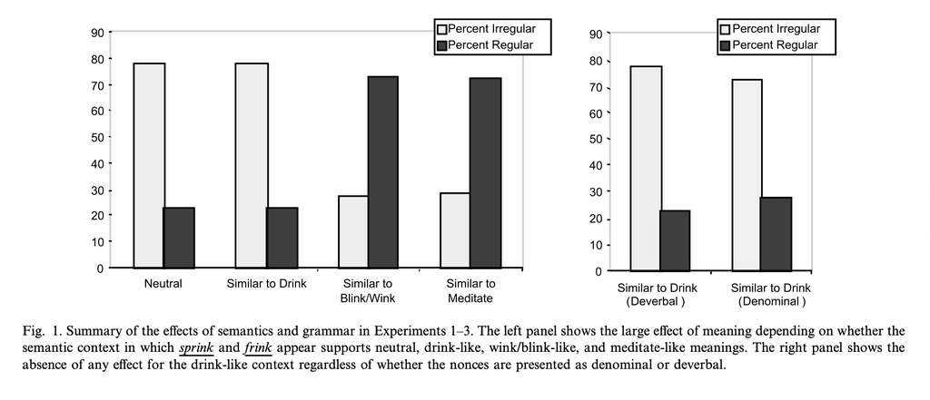

(Ramscar, 2002)

## Putting semantics into the single-route model

[interactive chart not shown]

# References

## References

Kim, J. J., Pinker, S., Prince, A., & Prasada, S. (1991). Why No Mere Mortal Has Ever Flown Out to Center Field. *Cognitive Science*, *15*(2), 173–218. https://doi.org/10.1207/s15516709cog1502_1

Pinker, S., & Prince, A. (1988). On Language and Connectionism:... *Cognition*, *28*(1-2), 73–193.

Ramscar, M. (2002). The role of meaning in inflection: Why the past tense does not require a rule. *Cognitive Psychology*, *45*(1), 45–94.

Rumelhart, D. E., & McClelland, J. L. (1986). On learning the past tenses of English verbs. *Parallel Distributed Processing: Explorations in the Microstructure of Cognition*, *2*, 216–271.